# Project 3: Analysing Returns of Financial Stocks

Group 8

2021-10-21

# 1 Returns of financial stocks

> You may find useful the material on [finance data sources](https://mfa2022.netlify.app/reference/finance_data/).

We will use the `tidyquant` package to download historical data of stock prices, calculate returns, and examine the distribution of returns.

We must first identify which stocks we want to download data for, and for this we must know their ticker symbol; Apple is known as AAPL, Microsoft as MSFT, McDonald’s as MCD, etc. The file `nyse.csv` contains 508 stocks listed on the NYSE, their ticker `symbol`, `name`, the IPO (Initial Public Offering) year, and the sector and industry the company is in.

```r
library(tidyquant)
nyse <- read_csv(here::here("data","nyse.csv"))
glimpse(nyse)
```

```
## Rows: 508
## Columns: 6
## $ symbol        <chr> "MMM", "ABB", "ABT", "ABBV", "ACN", "AAP", "AFL", "A", "…
## $ name          <chr> "3M Company", "ABB Ltd", "Abbott Laboratories", "AbbVie …
## $ ipo_year      <chr> "n/a", "n/a", "n/a", "2012", "2001", "n/a", "n/a", "1999…
## $ sector        <chr> "Health Care", "Consumer Durables", "Health Care", "Heal…
## $ industry      <chr> "Medical/Dental Instruments", "Electrical Products", "Ma…
## $ summary_quote <chr> "https://www.nasdaq.com/symbol/mmm", "https://www.nasdaq…
```

```r
skimr::skim(nyse)
```

Data summary

| Name | nyse |
| --- | --- |
| Number of rows | 508 |
| Number of columns | 6 |
| _______________________ |  |
| Column type frequency: |  |
| character | 6 |
| ________________________ |  |
| Group variables | None |

**Variable type: character**

| skim_variable | n_missing | complete_rate | min | max | empty | n_unique | whitespace |
| --- | --- | --- | --- | --- | --- | --- | --- |
| symbol | 0 | 1 | 1 | 4 | 0 | 508 | 0 |
| name | 0 | 1 | 5 | 48 | 0 | 505 | 0 |
| ipo_year | 0 | 1 | 3 | 4 | 0 | 33 | 0 |
| sector | 0 | 1 | 6 | 21 | 0 | 12 | 0 |
| industry | 0 | 1 | 5 | 62 | 0 | 103 | 0 |
| summary_quote | 0 | 1 | 31 | 34 | 0 | 508 | 0 |

Based on this dataset, create a table and a bar plot that shows the number of companies per sector, in descending order

```r
unique_companies <- nyse %>%
    distinct(symbol, name,ipo_year,.keep_all = TRUE)

#divide by sector
companies_per_sector <- unique_companies %>%
  group_by(sector) %>%
  count(sort=TRUE)
  companies_per_sector
```

```
## # A tibble: 12 × 2
## # Groups:   sector [12]
##    sector                    n
##    <chr>                 <int>
##  1 Finance                  97
##  2 Consumer Services        79
##  3 Public Utilities         60
##  4 Capital Goods            45
##  5 Health Care              45
##  6 Energy                   42
##  7 Technology               40
##  8 Basic Industries         39
##  9 Consumer Non-Durables    31
## 10 Miscellaneous            12
## 11 Transportation           10
## 12 Consumer Durables         8
```

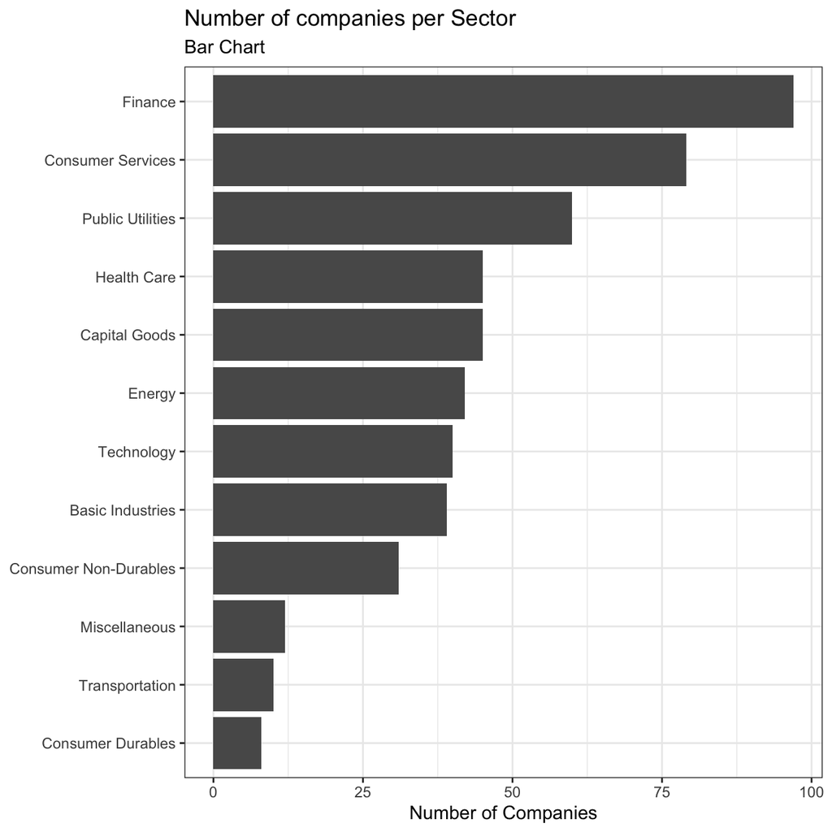

```r
companies_per_sector_plot <- unique_companies %>%
  group_by(sector) %>%
  count(sort=TRUE) %>%
  ggplot(aes( x = n, y = reorder(sector,n)))+
  geom_col()+
  theme_bw()+
      labs(title = "Number of companies per Sector",
        subtitle = "Bar Chart",
        x = "Number of Companies",
        y = NULL)

companies_per_sector_plot
```

The NYSE contains many more traditional industries (e.g. banks and insurance companies) which is why Finance and Consumer Services companies make up the highest number in the dataset. Many Technology companies instead choose to list on the NASDAQ, which explains why there are proportionately fewer Tech companies in this dataset.

Next, let’s choose the [Dow Jones Industrial Aveareg (DJIA)](https://en.wikipedia.org/wiki/Dow_Jones_Industrial_Average) stocks and their ticker symbols and download some data. Besides the thirty stocks that make up the DJIA, we will also add `SPY` which is an SP500 ETF (Exchange Traded Fund). The following code

```r
djia_url <- "https://en.wikipedia.org/wiki/Dow_Jones_Industrial_Average"


#get tables that exist on URL
tables <- djia_url %>%
  read_html() %>%
  html_nodes(css="table")


# parse HTML tables into a dataframe called djia.
# Use purr::map() to create a list of all tables in URL
djia <- map(tables, . %>%
               html_table(fill=TRUE)%>%
               clean_names())


# constituents
table1 <- djia[[2]] %>% # the second table on the page contains the ticker symbols
  mutate(date_added = ymd(date_added),

         # if a stock is listed on NYSE, its symbol is, e.g., NYSE: MMM
         # We will get prices from yahoo finance which requires just the ticker

         # if symbol contains "NYSE*", the * being a wildcard
         # then we jsut drop the first 6 characters in that string
         ticker = ifelse(str_detect(symbol, "NYSE*"),
                          str_sub(symbol,7,11),
                          symbol)
         )

# we need a vector of strings with just the 30 tickers + SPY
tickers <- table1 %>%
  select(ticker) %>%
  pull() %>% # pull() gets them as a sting of characters
  c("SPY") # and lets us add SPY, the SP500 ETF
```

```r
# Notice the cache=TRUE argument in the chunk options. Because getting data is time consuming, # cache=TRUE means that once it downloads data, the chunk will not run again next time you knit your Rmd

myStocks <- tickers %>%
  tq_get(get  = "stock.prices",
         from = "2000-01-01",
         to   = Sys.Date()) %>% # Sys.Date() returns today's price
  group_by(symbol)

glimpse(myStocks) # examine the structure of the resulting data frame
```

```
## Rows: 162,049
## Columns: 8
## Groups: symbol [31]
## $ symbol   <chr> "MMM", "MMM", "MMM", "MMM", "MMM", "MMM", "MMM", "MMM", "MMM"…
## $ date     <date> 2000-01-03, 2000-01-04, 2000-01-05, 2000-01-06, 2000-01-07, …
## $ open     <dbl> 48.0, 46.4, 45.6, 47.2, 50.6, 50.2, 50.4, 51.0, 50.7, 50.4, 4…
## $ high     <dbl> 48.2, 47.4, 48.1, 51.2, 51.9, 51.8, 51.2, 51.8, 50.9, 50.5, 4…
## $ low      <dbl> 47.0, 45.3, 45.6, 47.2, 50.0, 50.0, 50.2, 50.4, 50.2, 49.5, 4…
## $ close    <dbl> 47.2, 45.3, 46.6, 50.4, 51.4, 51.1, 50.2, 50.4, 50.4, 49.7, 4…
## $ volume   <dbl> 2173400, 2713800, 3699400, 5975800, 4101200, 3863800, 2357600…
## $ adjusted <dbl> 27.2, 26.1, 26.9, 29.0, 29.6, 29.4, 28.9, 29.0, 29.0, 28.6, 2…
```

Financial performance analysis depend on returns; If I buy a stock today for 100 and I sell it tomorrow for 101.75, my one-day return, assuming no transaction costs, is 1.75%. So given the adjusted closing prices, our first step is to calculate daily and monthly returns.

```r
#calculate daily returns
myStocks_returns_daily <- myStocks %>%
  tq_transmute(select     = adjusted,
               mutate_fun = periodReturn,
               period     = "daily",
               type       = "log",
               col_rename = "daily_returns",
               cols = c(nested.col))

#calculate monthly  returns
myStocks_returns_monthly <- myStocks %>%
  tq_transmute(select     = adjusted,
               mutate_fun = periodReturn,
               period     = "monthly",
               type       = "arithmetic",
               col_rename = "monthly_returns",
               cols = c(nested.col))


#calculate yearly returns
myStocks_returns_annual <- myStocks %>%
  group_by(symbol) %>%
  tq_transmute(select     = adjusted,
               mutate_fun = periodReturn,
               period     = "yearly",
               type       = "arithmetic",
               col_rename = "yearly_returns",
               cols = c(nested.col))
```

Create a table where you summarise monthly returns for each of the stocks and `SPY`; min, max, median, mean, SD.

```r
table_monthly_returns <- myStocks_returns_monthly %>%
  group_by(symbol) %>%
  summarise(
                mean_monthly_returns = mean(monthly_returns),
                min_ret=min(monthly_returns),
                max_ret = max(monthly_returns),
                mean_ret = mean(monthly_returns),
                median_ret = median(monthly_returns),
                sd_ret = sd(monthly_returns))

table_monthly_returns
```

```
## # A tibble: 31 × 7
##    symbol mean_monthly_returns min_ret max_ret mean_ret median_ret sd_ret
##    <chr>                 <dbl>   <dbl>   <dbl>    <dbl>      <dbl>  <dbl>
##  1 AAPL                0.0269   -0.577   0.454  0.0269     0.0352  0.115
##  2 AMGN                0.00816  -0.170   0.328  0.00816    0.00856 0.0732
##  3 AXP                 0.0102   -0.279   0.875  0.0102     0.0109  0.0921
##  4 BA                  0.0126   -0.458   0.459  0.0126     0.0165  0.0925
##  5 CAT                 0.0144   -0.353   0.350  0.0144     0.0141  0.0899
##  6 CRM                 0.0262   -0.360   0.403  0.0262     0.0205  0.110
##  7 CSCO                0.00609  -0.367   0.389  0.00609    0.0125  0.0962
##  8 CVX                 0.00896  -0.224   0.273  0.00896    0.0108  0.0655
##  9 DIS                 0.0104   -0.268   0.234  0.0104     0.00905 0.0737
## 10 DOW                 0.0160   -0.276   0.255  0.0160     0.0386  0.109
## # … with 21 more rows
```

The Dow Jones Industrial Average is a stock price-weighted index composed of 30 of the most important publicly-traded companies in the United. Due to this measure, we can observe some companies which have a smaller weighting have a larger market capitalization value. An example being Honeywell, which has a 4.29% weighting has a market capitalization of $152 billion. On the other hand, Apple only has a weighting 2.78%, yet has a total market capitalization of $2.43 trillion.

Plot a density plot, using `geom_density()`, for each of the stocks

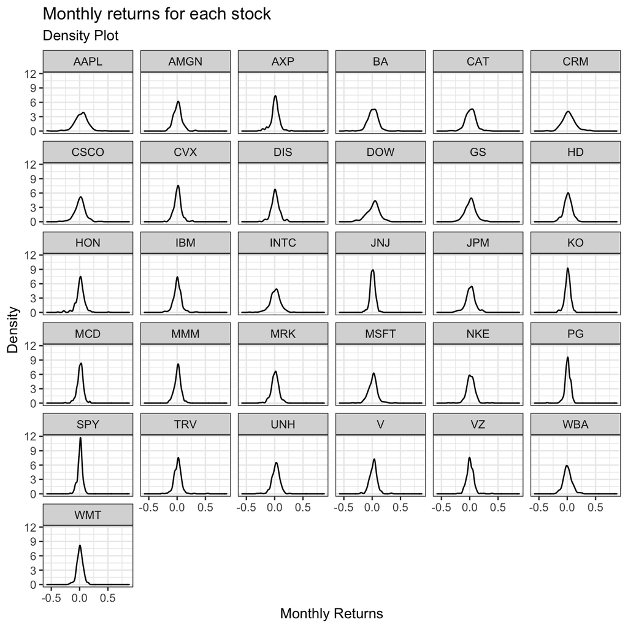

```r
density_monthly_returns <-
  ggplot(myStocks_returns_monthly, aes(x = monthly_returns)) +
  geom_density()+
  facet_wrap(~symbol)+
  theme_bw()+
  labs(title = "Monthly returns for each stock",
       subtitle="Density Plot",
       x = "Monthly Returns",
       y = "Density") +
       NULL

density_monthly_returns
```

What can you infer from this plot? Which stock is the riskiest? The least risky?

Finally, make a plot that shows the expected monthly return (mean) of a stock on the Y axis and the risk (standard deviation) in the X-axis. Please use `ggrepel::geom_text_repel()` to label each stock

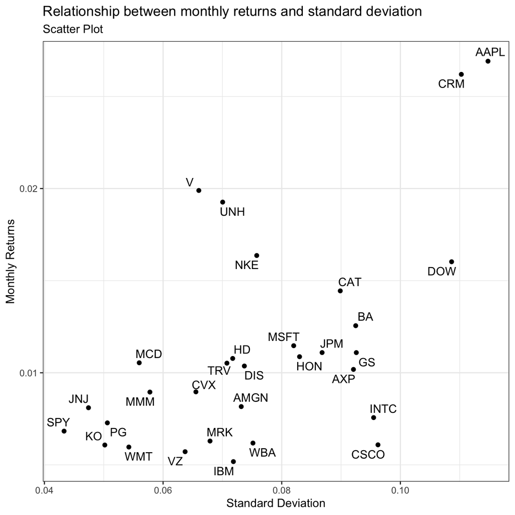

```r
library(ggrepel)


risk_return_plot <-
ggplot(table_monthly_returns, aes(x = sd_ret , y = mean_monthly_returns))+
  geom_point()+
  theme_bw()+
  labs(title = "Relationship between monthly returns and standard deviation",
       subtitle="Scatter Plot",
       x = "Standard Deviation",
       y = "Monthly Returns") +
       geom_text_repel(data = table_monthly_returns, aes(x = sd_ret , y = mean_monthly_returns, label = symbol))+
       NULL



risk_return_plot
```

```r
##
```

What can you infer from this plot? Are there any stocks which, while being riskier, do not have a higher expected return?

The graphs display different stock returns and their respective standard deviations representing the Efficient-market hypothesis. The stock with the lowest standard deviation, being the SPY (S&P 500 ETF) displays similar returns to other stocks with much higher risk. This can be explained by the previous theory, as unsystematic risk is not prized with higher returns. The relationship between stock returns and risk shows a very weak positive relationship. Excluding outliers such as AAPL and CRM, most stocks performance does not increase with risk. An example being JPM and CSCO stocks, which both have much more risk than stocks such as MCD PG, yet display similar returns.